# Radical YouTubers?

## Methodology

My data lack partisanship information that I can use as labels. Thus, I will use unsupervised learning algorithms to look at word frequencies. The first question is how to measure polarization. When labels exist, it is easy to identify clusters and from there, polarization could be estimated using that information, since we would look at how two well-defined groups behave.

Polarization means people think very differently (difference in means), and overlappings are not usual (cluster variance is small). Clusters that are homogeneous and separated represent a polarized situation. However, I do not have pre-existing labels in my dataset. Thus, my strategy is to construct two clusters and then measure polarization using these two clusters. I measure polarization following Mehlhaff (2021). I chose to use the cluster-polarization coefficient (CPC) because of its straightforward implementation to my data. This measure is designed to scale to high-dimensional analysis that incorporates distance and concentration of a distribution's component groups.

where each individual i in cluster k holds a position on dimension j.

To construct the two clusters, I follow five different strategies. First, I transform the document-term matrix to a tf-idf matrix. Given that some words are very frequent in speech, I prefer to give them less relevance than those that could be the ones that determine the conflict.

### NMF

I use Non-Negative Matrix Factorization (NMF) at every quarter with two topics. The entry j in the row i of the U matrix for a specific quarter correspond to the nonnegative components of the content-creator i in that quarter for the topic i. In my case, topics are what I consider as sources of conflict (or soft clusters) in the political dimension. If a document belongs to cluster j on a strong way, then it will have a very positive coordinate in the entry j of the row i. The coordinate will be zero or close to it if the document is not well represented by that cluster.

As a recap, these are the steps:

1. Transform the document-term matrix into the tf-idf at each quarter
2. factorize the matrix at each quarter to reduce the dimensionality to two clusters.
3. With the U matrix I project each creator to the [0,1] interval.
4. Clusterize the estimations in step 2 in two clusters, using k-means and hierarchichal clustering (two difwerent outcomes)
5. With the estimations in step 2 and clusters from step 3 I calculate a CPC for each quarter.

### Hierarchical Clustering

Second, I cluster at every quarter using the term-document matrix for that period. I do that using hierarchical clustering. Once I have two clusters, I calculate the CCP using the term-document matrix and the terms as the dimensions for the estimation.

As a recap, these are the steps:

1. Transform the document-term matrix into the tf-idf at each quarter
2. Clusterize the tf-idf in step 2 in two clusters
3. With the tf-idf, taking each term as a dimension, and clusters from step 1 I calculate a CPC for each quarter.

### Wordfish

Finally, to compare the results of the previous methods, I ran the R code to apply the Wordfish method (Slapin and Proksch, 2006). In this case, I use the matrix with the word counts instead of the tf-idf. After getting ideal positions for each creator-quarter, I cluster them into two groups (using either hierarchical clustering or k-means) and compute CPC at each quarter.

As a recap, these are the steps:

1. Calculate latent positions for content-creators at each quarter
2. Clusterize the estimations in step 2 in two clusters, using k-means and hierarchichal clustering (two difwerent outcomes)
3. With the estimations in step 1 and clusters from step 2 I calculate a CPC for each quarter.

### Validation

In order to validate, I will look at the cluster purity measure. In the five mentioned methods, I always end up having two groups. I would expect those clusters represent the left-right dimension of conflict. Thus, I compare the cluster that emerges from my methods with the labels from transparency.tube.

### Processing Data

```python
gf = pd.read_pickle('foo')
```

```python
D=gf.to_numpy()
E=D.transpose()
E
```

```
array([[0., 0., 0., ..., 0., 0., 0.],
       [0., 0., 0., ..., 0., 0., 0.],
       [0., 0., 0., ..., 0., 0., 0.],
       ...,
       [0., 0., 0., ..., 0., 0., 0.],
       [0., 0., 0., ..., 0., 0., 0.],
       [0., 0., 0., ..., 0., 0., 0.]])
```

```python
### Index list is id-month-year. I need to extract month and year from it.
### The output is a new column with the quarter: Q0 is first quarter of 2016.
gl=gf.transpose()
gl = gl[gl.columns[gl.sum()>2]]
li=gl.index.values.tolist()
di=[k.split('-') for k in li]
for k in range(0,len(di)):
    if len(di[k])==4:
        di[k][0 : 2]=['-'.join(di[k][0 : 2])]
    elif len(di[k])==5:
        di[k][0 : 3]=['-'.join(di[k][0 : 3])]
    elif len(di[k])==6:
        di[k][0 : 4]=['-'.join(di[k][0 : 4])]

t=0
for j in range(2016,2022):
    for i in range(0,4):
        for k in range(0,len(di)):
            if di[k][1]==str(i) and di[k][2]==str(j):
                f='Q'+str(t)
                di[k].append(f)
        t+=1

q=list(range(0,len(di)))
for k in range(0,len(di)):
    q[k]=di[k][3]
gl['Quarter'] = q
```

### Projections into the dimension of conflict and clustering

```python
## Quarter data + Tf-idf
tfidf_transformer = TfidfTransformer()
Dict = {}
t=0
for j in range(2016,2022):
    for i in range(0,4):
        f='Q'+str(t)
        A=gl[gl['Quarter'] == f]
        A = A.drop(columns=['Quarter'])
        A_tfidf = tfidf_transformer.fit_transform(A)
        gl[gl['Quarter'] == f].index.values.tolist()
        Dict[f] = [A, A_tfidf, gl[gl['Quarter'] == f].index.values.tolist()]
        t+=1
```

```python
## NMF
# From this I get a dictionary with quarters, the U matrix, the projections into the L/R dimension and the clustering over it.
nmf = NMF(n_components=2, solver="mu", max_iter=2000, tol=1e-10, beta_loss=1)
tfidf_transformer = TfidfTransformer()
DictNMF = {}
t=0
for j in range(2016,2022):
    for i in range(0,4):
        f= 'Q'+str(t)
        E= Dict[f][1].toarray()
        np.random.seed(42)
        Unnmf = nmf.fit_transform(E)
        VTnnmf= nmf.components_
        m=[None] * len(Unnmf)
        nmfhard=[None] * len(Unnmf)
        for j in range(0,len(Unnmf)):
            m[j]=np.arctan(Unnmf[j][0]*Unnmf[j][1])/math.pi
            nmfhard[j]=Unnmf[j][0]>Unnmf[j][1]
        linked = linkage(np.reshape(m, (len(m), 1)), 'ward')
        kmeans = KMeans(n_clusters=2, random_state=42).fit(np.reshape(m, (len(m), 1)))
        DictNMF[f] = [E, Unnmf, m, nmfhard, linked, kmeans]
        t+=1
```

```python
## Hierarchichal clustering
# From this I get a dictionary with quarters and the clustering over tf-idf matrix for each quarter.
Dict_hi = {}
t=0
for j in range(2016,2022):
    for i in range(0,4):
        f='Q'+str(t)
        A=gl[gl['Quarter'] == f]
        A = A.drop(columns=['Quarter'])
        A_tfidf = tfidf_transformer.fit_transform(A)
        A_m=A_tfidf.toarray()
        linked = linkage(A_m, 'ward')
        Dict_hi[f] = [A_m, linked ]
        t+=1
```

```python
## Wordfish
# From this I get a dictionary with quarters and the clustering over the coefficients calculated in wordfish
df = pd.read_csv(r'values_wf.csv', header=None)
df=df.iloc[:, 1]
wf = {}
wf= [gl.index.values.tolist(),df, gl['Quarter']]
wf=pd.DataFrame.from_dict(wf).T
w={}
for k in range(0,24):
    t=str(k)
    f='Q'+t
    A=wf[wf[2] == f][1]
    linked = linkage(np.reshape(list(A), (len(A), 1)), 'ward')
    kmeans = KMeans(n_clusters=2, random_state=42).fit(np.reshape(list(A), (len(A), 1)))
    w[f]=[A, linked, kmeans]
```

### CPC

```python
#NMF -> Projection -> Hierarchichal Clustering
CPC_NMF_ph={}
for k in range(0,24):
    t=str(k)
    f='Q'+t
    z=0
    y=0
    yr=0
    ze=0


    for i in range(0,len(DictNMF[f][1])):
        if cut_tree(DictNMF[f][4], n_clusters=[2])[i]==1:
            y += 1
            yr += DictNMF[f][2][i]
        elif cut_tree(DictNMF[f][4], n_clusters=[2])[i]==0:
            ze +=  DictNMF[f][2][i]
            z += 1
    ce_0 = ze/z
    ce_1 = yr/y
    centroid = (ze + yr)/(z+y )
    di_ce=0
    for i in range(0,len(DictNMF[f][1])):
        if cut_tree(DictNMF[f][4], n_clusters=[2])[i]==1:
            di_ce += (DictNMF[f][2][i]-ce_1)**2
        elif cut_tree(DictNMF[f][4], n_clusters=[2])[i]==0:
            di_ce += (DictNMF[f][2][i]-ce_0)**2
    di_cl = (ce_1-centroid)**2 + (ce_0-centroid)**2
    CPC_NMF_ph[f]=di_ce/(di_ce + di_cl)
```

```python
#NMF -> Projection -> K-means Clustering

CPC_NMF_pk={}
for k in range(0,24):
    t=str(k)
    f='Q'+t
    z=0
    y=0
    ce_0 = DictNMF[f][5].cluster_centers_[0]
    ce_1 = DictNMF[f][5].cluster_centers_[1]
    di_ce=0
    for i in range(0,len(DictNMF[f][1])):
        if DictNMF[f][5].labels_[i]==1:
            y += 1
            di_ce += (DictNMF[f][2][i].item()-ce_1)**2
        elif DictNMF[f][5].labels_[i]==0:
            z += 1
            di_ce += (DictNMF[f][2][i]-ce_0)**2
    centroid = (ce_0*z+ce_1*y)/(z+y)
    di_cl = (ce_1-centroid)**2 + (ce_0-centroid)**2
    CPC_NMF_pk[f]=di_ce/(di_ce + di_cl)
```

```python
#NMF -> Hierarchichal Clustering

t1_start = process_time()

CPC_h={}
for k in range(0,24):
    t=str(k)
    f='Q'+t

    A=pd.DataFrame(Dict_hi[f][0]).loc[:, pd.DataFrame(Dict_hi[f][0]).sum(axis=0)>0]

    B = {}
    lat_list = [item for sublist in cut_tree(Dict_hi[f][1], n_clusters=[2]) for item in sublist]
    di_cl=[0.0] * len(A.loc[0,:])
    di_ce0=[0.0] * len(A.loc[0,:])
    di_ce1=[0.0] * len(A.loc[0,:])
    for j in range(0,len(A.loc[0,:])):   #loop over words
        ce_0 = A.iloc[:,j].groupby(lat_list).mean()[0]
        ce_1 = A.iloc[:,j].groupby(lat_list).mean()[1]
        centroid = A.iloc[:,j].mean()
        di_cl[j] = (ce_1-centroid)**2 + (ce_0-centroid)**2
        di_ce1[j] = (A.iloc[:,j]-ce_1)**2
        di_ce0[j] = (A.iloc[:,j]-ce_0)**2
    x = pd.DataFrame(di_ce1).T.groupby(lat_list).sum().iloc[1,:].sum() + pd.DataFrame(di_ce0).T.groupby(lat_list).sum().iloc[0,:].sum()
    q = np.sum(di_cl)
    CPC_h[f]=x/(x + q)
```

```python
#Wordfish -> Hierarchichal Clustering

CPC_wf_h={}
for k in range(0,24):
    t=str(k)
    f='Q'+t
    z=0
    y=0
    yr=0
    ze=0

    for i in range(0,len(wf[wf[2] == f][1])):
        if cut_tree(w[f][1], n_clusters=[2])[i]==1:
            y += 1
            yr += wf[wf[2] == f][1][i:i+1].item()
        elif cut_tree(w[f][1], n_clusters=[2])[i]==0:
            ze +=  wf[wf[2] == f][1][i:i+1].item()
            z += 1
    ce_0 = ze/z
    ce_1 = yr/y
    centroid = (ze + yr)/(z+y )
    di_ce=0
    for i in range(0,len(wf[wf[2] == f][1])):
        if cut_tree(w[f][1], n_clusters=[2])[i]==1:
            di_ce += (wf[wf[2] == f][1][i:i+1].item()-ce_1)**2
        elif cut_tree(w[f][1], n_clusters=[2])[i]==0:
            di_ce += (wf[wf[2] == f][1][i:i+1].item()-ce_0)**2
    di_cl = (ce_1-centroid)**2 + (ce_0-centroid)**2
    CPC_wf_h[f]=di_ce/(di_ce + di_cl)
```

```python
#Wordfish -> K-Means Clustering

CPC_wf_k={}
for k in range(0,24):
    t=str(k)
    f='Q'+t
    z=0
    y=0
    ce_0 = w[f][2].cluster_centers_[0]
    ce_1 = w[f][2].cluster_centers_[1]
    di_ce=0
    for i in range(0,len(w[f][0])):
        if w[f][2].labels_[i]==1:
            y += 1
            di_ce += (w[f][0][i:i+1].item()-ce_1)**2
        elif w[f][2].labels_[i]==0:
            z += 1
            di_ce += (w[f][0][i:i+1].item()-ce_0)**2
    centroid = (ce_0*z+ce_1*y)/(z+y)
    di_cl = (ce_1-centroid)**2 + (ce_0-centroid)**2
    CPC_wf_k[f]=di_ce/(di_ce + di_cl)
```

## Results

I could only get from the results that polarization has not dramatically changed over the last five years. In all measures, we see some fluctuations, but the trend seems to be constant. Using Wordfish, polarization seems to be cyclical, and we are in an upward trend now. However, this is not something we can see with the other three measures.

Thus, it seems complicated to support a statement that we see rising polarization and bias on social media content and this is robust to the different strategies. Although this is a small sample of content creators, there is still no evidence that shows that polarization is increasing on the content. This result is surprising given that, as mentioned in the introduction, YouTube is considered a source of radicalization.

The result means that the polarization in vocabulary use between the two most prominent groups (in terms of these differences) has not increased. There are two factors that affect this measure: distance between clusters and homogeneity of each of both clusters. Future work could look at both dimensions and see if both do not show any change, or maybe they went in different directions.

[figure not shown]

```python
plt.plot(list(CPC_NMF_ph.keys()),list(CPC_NMF_ph.values()))
plt.title("CPC for NMF -> Projection -> Hierarchichal Clustering")
```

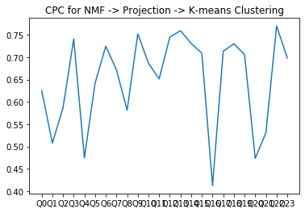

```python
plt.plot(list(CPC_NMF_pk.keys()),list(CPC_NMF_pk.values()))
plt.title("CPC for NMF -> Projection -> K-means Clustering")
```

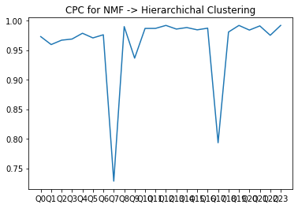

```python
plt.plot(list(CPC_h.keys()),list(CPC_h.values()))
plt.title("CPC for NMF -> Hierarchichal Clustering")
```

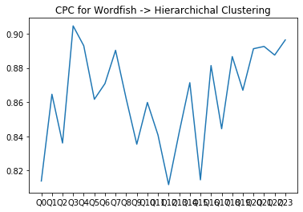

```python
plt.plot(list(CPC_wf_h.keys()),list(CPC_wf_h.values()))
plt.title("CPC for Wordfish -> Hierarchichal Clustering")
```

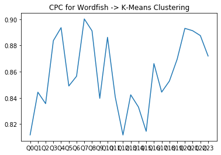

```python
plt.plot(list(CPC_wf_k.keys()),list(CPC_wf_k.values()))
plt.title("CPC for Wordfish -> K-Means Clustering")
```

## Validation

```python
df = pd.read_csv(r'channels_lab.csv')
```

```python
[item for sublist in cut_tree(Dict_hi[f][1], n_clusters=[2]) for item in sublist];
```

```python
li=gl.index.values.tolist()
li
```

[output not shown]

[output cut: 739 more lines]

```
 'UU9ISPZsMaBi5mutsgX6LC1g-1-2019',
 'UU9ISPZsMaBi5mutsgX6LC1g-2-2019',
 'UU9ISPZsMaBi5mutsgX6LC1g-3-2019',
 'UU9ISPZsMaBi5mutsgX6LC1g-0-2020',
 'UU9ISPZsMaBi5mutsgX6LC1g-1-2020',
 'UU9ISPZsMaBi5mutsgX6LC1g-2-2020',
 'UU9ISPZsMaBi5mutsgX6LC1g-3-2020',
 'UU9ISPZsMaBi5mutsgX6LC1g-0-2021',
 'UU9ISPZsMaBi5mutsgX6LC1g-1-2021',
 'UU9ISPZsMaBi5mutsgX6LC1g-2-2021',
 'UU9ISPZsMaBi5mutsgX6LC1g-3-2021',
 'UUA071Pllf2wk-B8Rkwt47bQ-3-2020',
 'UUA071Pllf2wk-B8Rkwt47bQ-0-2021',
 'UUA071Pllf2wk-B8Rkwt47bQ-1-2021',
 'UUA071Pllf2wk-B8Rkwt47bQ-2-2021']
```

```python
di=[k.split('-') for k in li]
for k in range(0,len(di)):
    if len(di[k])==4:
        di[k][0 : 2]=['-'.join(di[k][0 : 2])]
    elif len(di[k])==5:
        di[k][0 : 3]=['-'.join(di[k][0 : 3])]
    elif len(di[k])==6:
        di[k][0 : 4]=['-'.join(di[k][0 : 4])]
```

```python
di = pd.DataFrame(di, columns =['id', 'm', 'y'])
## merge both dfs, merge with di
df['id']=df['id'].str.strip()
gi = pd.merge(di, df, on='id')
```

```python
ei = [0.0] *len(gi)

t=0
for j in range(2016,2022):
    for i in range(0,4):
        for k in range(0,len(gi)):
            if gi.loc[k,'m']==str(i) and gi.loc[k,'y']==str(j):
                f='Q'+str(t)
                ei[k]=f
        t+=1

gi['Quarter']=ei
```

```python
dictpur={}
for k in range(0,24):
    t=str(k)
    f='Q'+t
    lab_NMF_phi=[item for sublist in cut_tree(DictNMF[f][4], n_clusters=[2]) for item in sublist]
    lab_NMF_pk=  DictNMF[f][5].labels_
    lab_wf_h= [item for sublist in cut_tree(w[f][1], n_clusters=[2]) for item in sublist]
    lab_wf_k=w[f][2].labels_
    lab_hi= [item for sublist in cut_tree(Dict_hi[f][1], n_clusters=[2]) for item in sublist]
    dictpur[f]= [gi[gi['Quarter']==f] ,lab_NMF_phi, lab_NMF_pk, lab_wf_h, lab_wf_k,lab_hi]
```

```python
dictpur2={}
for k in range(0,24):
    t=str(k)
    f='Q'+t
    lr = gi[gi['Quarter']==f]['classif2'].tolist()
    d = {"labels": lr, "lab_NMF_phi": dictpur[f][1], "lab_NMF_pk": dictpur[f][2], "lab_wf_h": dictpur[f][3], "lab_wf_k": dictpur[f][4] , "lab_hi": dictpur[f][5]}
    df2 = pd.DataFrame(d)
    dictpur2[f] = df2
```

```python
names=["lab_NMF_phi", "lab_NMF_pk", "lab_wf_h",  "lab_wf_k", "lab_hi"]
pur3={}
for k in names:
    purli=[None] * len(range(0,24))
    purli2=[None] * len(range(0,24))
    for i in range(0,24):
        t=str(i)
        f='Q'+t
        purli[i] = (max(pd.crosstab(dictpur2[f][k], dictpur2[f]['labels'])[1][0],pd.crosstab(dictpur2[f][k], dictpur2[f]['labels'])[0][0])+max(pd.crosstab(dictpur2[f][k], dictpur2[f]['labels'])[0][1],pd.crosstab(dictpur2[f][k], dictpur2[f]['labels'])[1][1]))/len(dictpur2[f])
        purli2[i] = 1- dictpur2[f]['labels'].sum()/len(dictpur2[f])
    pur3[k]=[purli,purli2]
```